# Primera Champions del Manchester City

Rafael Graziani, Freddy Melgarejo, Salvador Nesta y Anselmo Velazco

2023-06-14

# Carga de archivos y librerías

Para la correcta realización de este informe, son necesarios los siguientes paquetes para que los scripts presentes funcionen de forma óptima y sin complicación alguna. A continuación, las librerías a utilizar:

```r
library(tidyverse)
```

```r
library(readxl)
library(ggthemes)
library(ggplot2)
library(ggrepel)
library(knitr)
library(gridExtra)
library(RColorBrewer)
library(dplyr)
```

Una vez con las librerías activadas, se procede a leer el archivo Excel en donde se poseen los datos limpios extraídos de la base de datos original.

```r
stats_top16 <- read_excel("C:/Users/ansel/OneDrive/Documents/Top 16 Champions League 22 y 23.xlsx")
```

# Introducción

El Manchester City se ha coronado campeón de la UEFA Champions League este 10 de junio de 2023. Fue un hecho histórico para el equipo inglés, ya que nunca en la historia habían ganado este trofeo.

Para el siguiente informe, usamos la base de datos proporcionada por la UEFA en su página oficial, en la cual se registran todas las estadísticas de esta edición de Champions 2022/2023.

Ahora bien, para la realización del mismo, decidimos analizar los números de cada equipo que llegó a los octavos de final. Esto con el fin de plantearnos como pregunta general, si el City, en cuanto a indicadores futbolísticos, respalda que por fin haya ganado la UEFA Champions League.

Con el propósito de únicamente usar datos que se consideran relevantes para medir el éxito y desempeño de un equipo, se hizo una recopilación de 25 variables; algunas de ellas son: goles, pases completados, porterías imbatidas, cantidad de dribles realizados, tiros a puerta, entre otros

Cabe destacar, que dentro de la data extraída no existían indicadores que los investigadores consideran interesantes de analizar. No obstante, los mismos se podían calcular usando variables contenidas en la base de datos, por lo cual se procedió a realizar el cálculo de indicadores como: goles promedio por partido, dribles promedio por partido, tasa de conversión de goles, goles por cada intento.

A continuación se detallan los cálculos mencionados anteriormente:

1. Cálculo de goles promedio por partido por equipo

```r
stats_top16 <- stats_top16 %>%
  mutate(Goles_Prom =
           round(Goles/Partidos_Jugados,
                 digits = 2))
```

2. Cálculo de dribles promedio por partido por equipo

```r
stats_top16 <- stats_top16 %>%
  mutate(Dribles_Prom =
           round(Dribles/Partidos_Jugados,
                 digits = 2))
```

3. Cálculo de cuántos intentos de tiros a puerta le hace falta a cada equipo para convertir el gol

```r
stats_top16 <- stats_top16 %>%
  mutate(`% Conversion` =
           round(Goles/Intentos_a_puerta,
                 digits= 2)) %>%
  mutate(GolxIntento =
           round(1/`% Conversion`,
                 digits = 2))
```

## Presentación de los datos

El tópico seleccionado, principalmente genera un ambiente de intriga entre los investigadores, ya que la primera Champions de un equipo es un tema importante, abierto a opiniones y polémica sobre el merecimiento del trofeo. Nuestro objetivo principal es determinar si, el logro del City, está respaldado por lo que demostraban en el campo. Por otro lado, la intención del mismo es plantear y sembrar cuestiones interesantes que se puedan indagar, analizar y estudiar a profundidad.

### ¿Por qué es relevante esta investigación?

Consideramos que esta investigación es relevante porque sirve de guía para aquellas personas que les gusta entender el fútbol y sobre todo para los entrenadores de fútbol que buscan y aspiran conseguir más títulos, ya que les brinda conocimientos clave sobre áreas de oportunidad en las que se debe poner a trabajar con sus jugadores para mejorar cada día esos aspectos que tienen un impacto positivo en los partidos.

### Hallazgos iniciales

En primera instancia, descubrimos que el campeón de esta edición de la UEFA Champions League no perdió ni un solo partido. Por lo que surgieron ciertas cuestiones que planteamos a continuación:

#### Planteamientos

- Analizar la relación entre variables relevantes para evaluar el desempeño de los equipos en una competición deportiva.
- Determinar si existe una correlación entre dos o más variables y cómo esta puede afectar el desempeño de los equipos.
- Evaluar el desempeño de los equipos en términos de su eficacia en la generación de oportunidades de gol y en la definición de las jugadas.
- Comparar la eficacia de cada equipo o club en relación con los demás equipos de su grupo.
- Identificar patrones interesantes en los datos que permitan entender mejor el desempeño de los equipos.

# Análisis Descriptivo

### Gráfica 1

En la gráfica se presenta la información de la siguiente manera: Cada uno de los puntos representa un equipo. En el eje X se muestra el número promedio de dribles por partido para cada equipo, mientras que el eje Y muestra la cantidad de ataques generados por los mismos. El tamaño de los puntos representa el número promedio de dribles por partido, lo que permite identificar fácilmente los equipos con los promedios más altos.

Adicionalmente, los puntos están diferenciados por colores, según el club al que pertenece cada equipo, para esto se utilizó la paleta de colores “Set1” de la librería RColorBrewer.

Finalmente, y para facilitar la lectura e interpretación de la misma, se agrega la leyenda a los lados de la gráfica, la cual muestra el número promedio de dribles por partido de cada equipo en la parte derecha, mostrando el rango en la cual está cada punto según su tamaño, los nombres de los clubes a los cuales pertenece cada punto según su color, y en cada punto correspondiente para facilitar la identificación de cada equipo.

En resumen, esta gráfica ayuda a identificar la relación entre el número de dribles por partido de los equipos y su capacidad para generar peligro en ataque, y permite comparar el desempeño de los equipos en ambos aspectos.

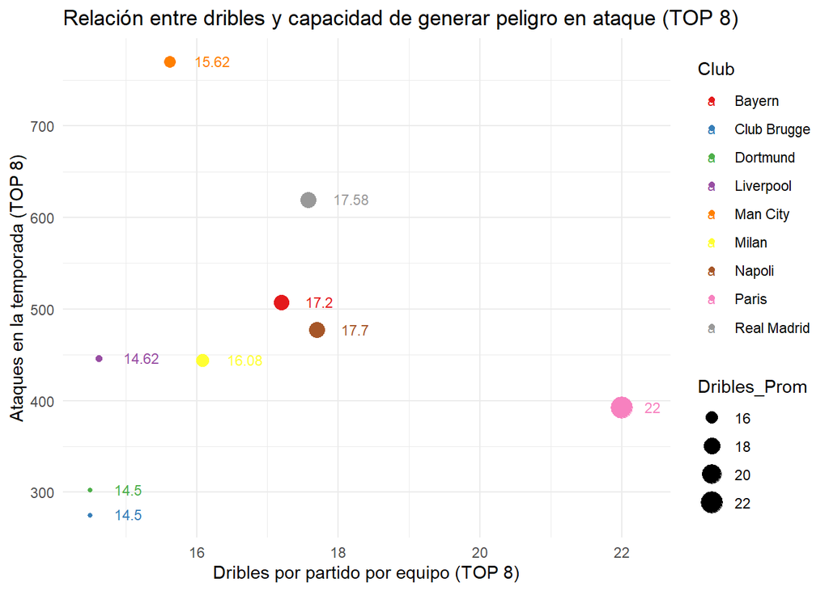

```r
# Se seleccionan los 8 equipos con el mayor promedio de dribles por partido para
# hacer más representativa y más entendible la gráfica:

stats_top16 %>%
  top_n(8, Dribles_Prom) %>%

  # Se crea el gráfico de puntos:

  ggplot(aes(x = Dribles_Prom, y = Ataques,
             color = Club,
             label = Dribles_Prom,
             size = Dribles_Prom)) +
  geom_point() +

  # Se agregan las etiquetas de los puntos:
  geom_text(hjust = -0.1,
            vjust = 0.5,
            nudge_x = 0.3,
            nudge_y = 1,
            size = 3) +

  # Se selecciona una paleta de colores diferenciables:
  scale_color_brewer(palette = "Set1") +

  # Se agregan las etiquetas a los ejes y título al gráfico:
  labs(x = "Dribles por partido por equipo (TOP 8)",
       y = "Ataques en la temporada (TOP 8)",
       title = "Relación entre dribles y capacidad de generar peligro en ataque (TOP 8)") +

  # Se elige el tema del gráfico:
  theme_minimal()
```

### Gráfica 2

Al correr este código, se nos genera una gráfica de dispersión que muestra la relación entre el número de goles anotados y la cantidad de intentos al arco (puerta) hechos por cada equipo en la variable stats_top16. Al igual que en la gráfica anterior, cada punto representa un equipo, diferenciados por color y mostrados a un lado en la leyenda. El eje x muestra el número de goles anotados por cada equipo, mientras que el eje y muestra la cantidad de intentos al arco hechos por los mismos.

La gráfica permite visualizar los datos de manera que, si los puntos están estrechamente agrupados en una línea recta, indica una fuerte correlación lineal entre las dos variables, por otro lado, si los puntos están dispersos y/o sin un patrón claro, entonces es sinónimo de una correlación débil o inexistente.

La cantidad de intentos a puerta que un equipo genera también puede ser un indicador de su capacidad ofensiva y su estrategia de juego. Por lo tanto, esta gráfica puede ser útil para evaluar el desempeño de los equipos en términos de su eficacia de oportunidades de gol generadas.

En resumen, esta gráfica es una herramienta útil para visualizar la relación entre el número de goles anotados y la cantidad de intentos a puerta generados por cada equipo en stats_top16, lo que permite evaluar el desempeño de los equipos en términos de su eficacia en la generación de oportunidades de gol y en la definición de las jugadas.

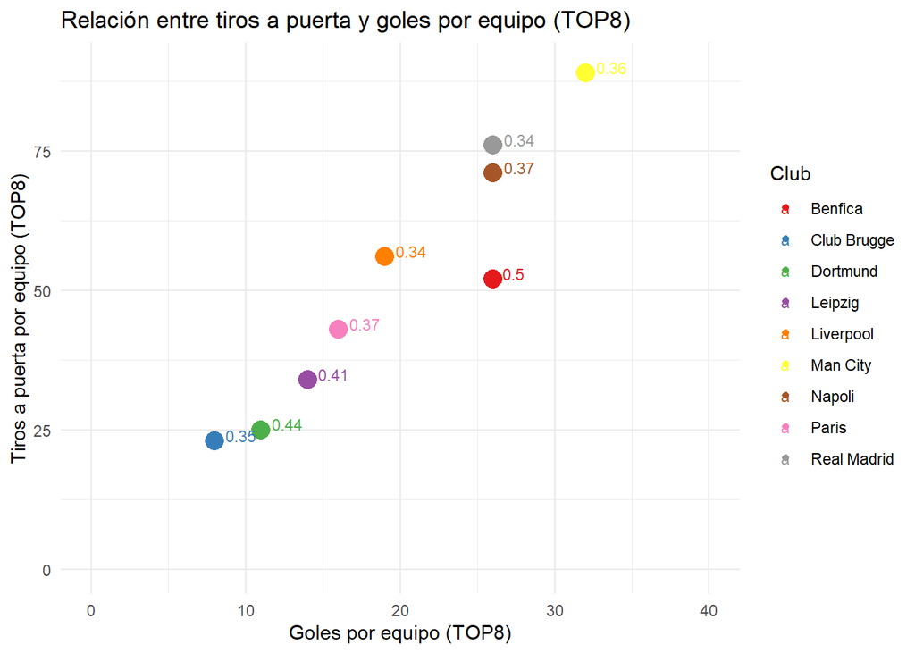

```r
# Se seleccionan los 8 equipos con el mayor promedio de porcentaje de conversión,
# para hacer más representativa y más entendible la gráfica:

stats_top16 %>%
  top_n(8, `% Conversion`) %>%

  # Se crea el gráfico de puntos:

  ggplot(aes(x = Goles, y = Intentos_a_puerta,
             color = Club,
             label = `% Conversion`,
             size = 10)) +
  geom_point() +

  # Se agregan las etiquetas de los puntos:

  geom_text(hjust = -0.1,
            vjust = 0.5,
            nudge_x = 0.5,
            nudge_y = 1,
            size = 3) +

  # Se elige una paleta de colores que sean diferenciables:

  scale_color_brewer(palette = "Set1") +

  # Se elimina la leyenda del tamaño de los puntos, pues no es necesaria:

  scale_size(guide = "none") +

  # Agregamos etiquetas a los ejes y título al gráfico:

  labs(x = "Goles por equipo (TOP8)",
       y = "Tiros a puerta por equipo (TOP8)",
       title = "Relación entre tiros a puerta y goles por equipo (TOP8)") +

  # Establecemos los límites de los ejes para que se alcance a ver todo bien:

  coord_cartesian(xlim = c(0, 40),
                  ylim = c(0, 90)) +

  # Elegimos el tema del gráfico:

  theme_minimal()
```

### Gráfica 3

En último lugar, pero para nada menos interesante, tenemos dos gráficas de barras que muestran la relación entre el número de goles anotados y la cantidad de intentos a puerta generados por cada club de Alemania y de Inglaterra, respectivamente.

Para esto, se filtran los datos para incluir solo los clubes de Alemania y de Inglaterra, respectivamente, luego se calcula el promedio de goles por intento a puerta para cada grupo de clubes.

De esta manera se crean entonces dos gráficas de barras utilizando la librería ggplot2. En cada gráfica el eje X muestra el nombre de cada club, mientras que el eje Y muestra el número de goles por intento a puerta. Los colores de las barras, al igual que se presentaba con los puntos en los gráficos de dispersión anteriores, se determinan por el nombre del club.

La línea horizontal punteada de color rojo en cada gráfica representa el promedio de goles por intento a puerta para el grupo correspondiente de clubes. Esto permite comparar visualmente la eficacia de cada club en la relación intentos a puerta - goles con el promedio para su grupo.

Finalmente, se combinan las dos gráficas en un mismo espacio gráfico utilizando la función grid.arrange() de la librería gridExtra. Esto permite comparar fácilmente la eficacia de cada club en la conversión de intentos a puerta en goles entre los clubes de Alemania y de Inglaterra.

En resumen, estas gráficas de barras permiten comparar la eficacia de cada club en la conversión de intentos a puerta en goles para los clubes de Alemania y de Inglaterra en stats_top16. Esto puede ser útil para analizar el desempeño de los equipos y comparar su capacidad ofensiva en relación con los demás equipos de su grupo.

```r
# Se crean vectores de club y país para posteriormente agregar a la tabla de estadísticas generales:

club <- c("Man City", "Inter", "Real Madrid", "Milan", "Bayern", "Napoli",
          "Benfica", "Chelsea", "Liverpool", "Paris", "Porto", "Leipzig",
          "Dortmund", "Tottenham","Club Brugge", "Frankfurt")

pais <- c("Inglaterra", "Italia", "España", "Italia", "Alemania", "Italia",
          "Portugal", "Inglaterra", "Inglaterra", "Francia", "Portugal",
          "Alemania", "Alemania", "Inglaterra", "Bélgica", "Alemania")

# Se crea el dataframe de clubes y países:

club_por_pais <- data.frame(Club = club,
                            Pais = pais)

# Se unen los datos de estadísticas general con los datos de clubes y países:

stats_top16 <- stats_top16 %>%
  left_join(club_por_pais,
            by = "Club")

# Seleccionar las columnas relevantes
stats_top16 <- stats_top16 %>%
  select(Club, Pais, Partidos_Jugados, Ganados, Empates, Perdidos, Goles,
         Ataques, Asistencias, Dribles, Total_intentos, Intentos_a_puerta,
         Intentos_fuera_de_puerta,  `Precisión_pases(%)`, Pases_intentados,
         Pases_completados, `Posesión(%)`, Balones_recuperados, Tacleadas,
         Tacleadas_ganadas, Despejes_intentados, Salvadas, Goles_concedidos,
         Salvadas_penalti, Porterías_limpias, Goles_Prom, Dribles_Prom,
         `% Conversion`, GolxIntento)
```

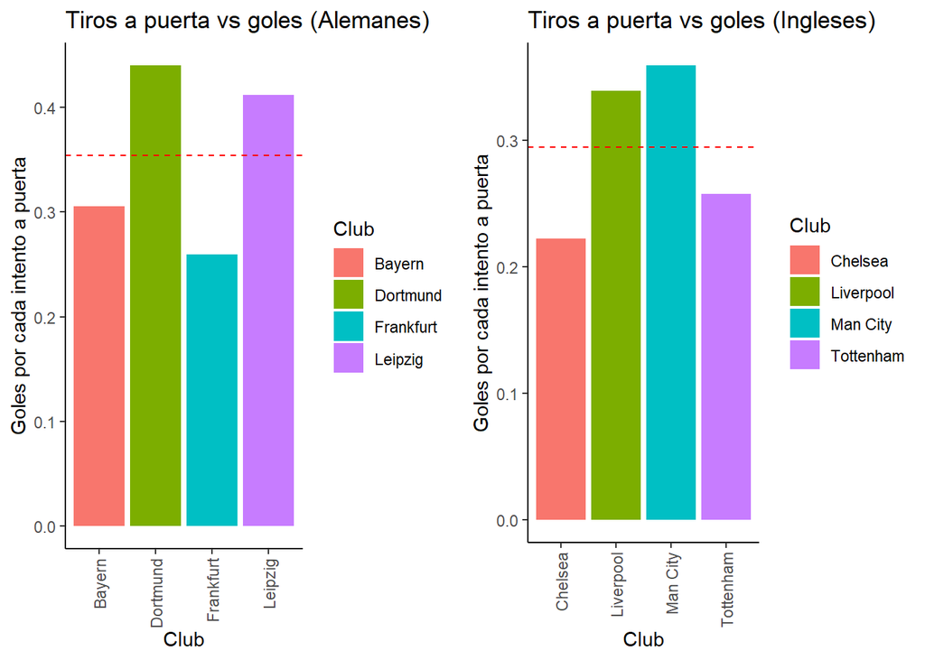

```r
# Filtramos los datos para incluir solo los clubes alemanes:

stats_alemania <- stats_top16 %>%
  filter(Pais == "Alemania")

# Se calcula el promedio de goles por intento a puerta para los clubes alemanes:

promedio_goles_alemania <- stats_alemania %>%
  summarise(mean(Goles / Intentos_a_puerta))

# Creamos la gráfica de barras para los clubes alemanes:

grafica_alemana <- ggplot(stats_alemania, aes(x = Club,
                                              y = Goles/Intentos_a_puerta,
                                              fill = Club)) +
  geom_bar(stat = "identity") +
  labs(x = "Club",
       y = "Goles por cada intento a puerta",
       title = "Tiros a puerta vs goles (Alemanes)") +
  geom_hline(yintercept = pull(promedio_goles_alemania),
             linetype = "dashed",
             color = "red") +

# Elegimos tema para la gráfica:

  theme_classic() +
  theme(axis.text.x = element_text(angle = 90,
                                   vjust = 0.5,
                                   hjust = 1))

# Filtramos los datos para incluir solo los clubes ingleses:

stats_inglaterra <- stats_top16 %>%
  filter(Pais == "Inglaterra")

# Calculamos el promedio de goles por intento a puerta para los clubes ingleses:

promedio_goles_inglaterra <- stats_inglaterra %>%
  summarise(mean(Goles / Intentos_a_puerta))

# Crear la gráfica de barras para los clubes ingleses
grafica_inglesa <- ggplot(stats_inglaterra, aes(x = Club,
                                                y = Goles/Intentos_a_puerta,
                                                fill = Club)) +
  geom_bar(stat = "identity") +
  labs(x = "Club",
       y = "Goles por cada intento a puerta",
       title = "Tiros a puerta vs goles (Ingleses)") +
  geom_hline(yintercept = pull(promedio_goles_inglaterra),
             linetype = "dashed",
             color = "red") +

# Elegimos tema para la gráfica:

  theme_classic() +
  theme(axis.text.x = element_text(angle = 90,
                                   vjust = 0.5,
                                   hjust = 1))

# Finalmente se combinan las gráficas en un mismo espacio gráfico para comparar:

grid.arrange(grafica_alemana,
             grafica_inglesa,
             ncol = 2)
```

# Conclusiones

Ahora bien, con el fin de fomentar al estudio de este caso, se plantea la siguiente interrogante para que esta pueda ser estudiada y analizada a mayor profundidad mediante otra investigación: ¿La contratación de un delantero 9 como Erling Haaland fue el detonante que llevó al City a ganar su primera Champions? ¿Qué tanto influyó en el equipo?

En este caso habría que comparar las estadísticas históricas del Manchester City para dar respuesta a este planteamiento.

# Referencias

- UEFA (2022/2023). UEFA Champions League - Statistics - Clubs. Recuperado el 14 de junio de 2023, de https://www.uefa.com/uefachampionsleague/statistics/clubs/
- UEFA. (2022/2023). UEFA Champions League - Statistics - Clubs - Goals. Recuperado el 14 de junio de 2023, de https://www.uefa.com/uefachampionsleague/statistics/clubs/goals/
- UEFA. (2022/2023). UEFA Champions League - Statistics - Clubs - Attempts. Recuperado el 14 de junio de 2023, de https://www.uefa.com/uefachampionsleague/statistics/clubs/attempts/
- UEFA. (2022/2023). UEFA Champions League - Statistics - Clubs - Distribution. Recuperado el 14 de junio de 2023, de https://www.uefa.com/uefachampionsleague/statistics/clubs/distribution/
- UEFA. (2022/2023). UEFA Champions League - Statistics - Clubs - Attacking. Recuperado el 14 de junio de 2023, de https://www.uefa.com/uefachampionsleague/statistics/clubs/attacking/
- UEFA. (2022/2023). UEFA Champions League - Statistics - Clubs - Defending. Recuperado el 14 de junio de 2023, de https://www.uefa.com/uefachampionsleague/statistics/clubs/defending/
- UEFA. (2022/2023). UEFA Champions League - Statistics - Clubs - Goalkeeping. Recuperado el 14 de junio de 2023, de https://www.uefa.com/uefachampionsleague/statistics/clubs/goalkeeping/
- UEFA. (2022/2023). UEFA Champions League - Statistics - Clubs - Disciplinary. Recuperado el 14 de junio de 2023, de https://www.uefa.com/uefachampionsleague/statistics/clubs/disciplinary/